# Solutions for Univariate visualization and summaries

## Exercise 1: Get curious

- Results of brainstorming themes will vary
- From the “Data and Method” section at the end of the Pudding article, we see this paragraph:

> The writers of these questions likely skew roughly 2/3 female (according to Pauline Phillips, who mentions the demographics of responses to a survey she disseminated in 1987), and consequently, their interests are overrepresented; we’ve been unable to find other demographic data surrounding their origins. There is, doubtless, a level of editorializing here: only a fraction of the questions that people have written in have seen publication, because agony aunts (the writers of advice columns) must selectively filter what gets published. Nevertheless, the concerns of the day seem to be represented, such as the HIV/AIDS crisis in the 1980s. Additionally, we believe that the large sample of questions in our corpus (20,000+) that have appeared over recent decades gives a sufficient directional sense of broad trends.
- Writers of the questions are predominately female. The 2/3 proportion was estimated in 1987, so it would be useful to understand shifts in demographics over time.
- What questions were chosen to be answered on the column? Likely a small fraction of what got submitted. What themes tended to get cut out?

## Exercise 2: Importing and getting to know the data

```r
# Load package
library(tidyverse)
library(readr)

# Read in the course evaluation data
abby <- read_csv("https://mac-stat.github.io/data/dear_abby.csv")
```

1. Note how clicking the `abby` data causes both a popup pane and the command `View(abby)` to appear in the Console. In fact, the `View()` function is the underlying command that opens a dataset pane. (`View()` should always be entered in the Console and NOT your Quarto document.)
2. Each row / case corresponds to a single question.
3. Columns = variables
4. Try out each function below. Identify what each function tells you about the `abby` data and note this in the `???`:

```r
# First number = number of rows / cases
# Second number = number of columns / variables
dim(abby)
```

```
[1] 20034    11
```

```r
# Number of rows (cases)
nrow(abby)
```

```
[1] 20034
```

```r
# Number of columns (variables)
ncol(abby)
```

```
[1] 11
```

```r
# View first few rows of the dataset (6 rows, by default)
head(abby)
```

```
# A tibble: 6 × 11
   year month day   url     title letterId question_only afinn_overall afinn_pos
  <dbl> <dbl> <chr> <chr>   <chr>    <dbl> <chr>                 <dbl>     <dbl>
1  1985     1 01    proque… WOMA…        1 "i have been…           -30         5
2  1985     1 01    proque… WOMA…        1 "this is for…           -30         5
3  1985     1 02    proque… LAME…        1 "our 16-year…             1         3
4  1985     1 03    proque… 'NOR…        1 "i was a hap…            -3         7
5  1985     1 04    proque… IT'S…        1 "you be the …            13        31
6  1985     1 04    proque… IT'S…        1 "a further w…            13        31
# ℹ 2 more variables: afinn_neg <dbl>, bing_pos <dbl>
```

```r
# Get all column (variable) names
names(abby)
```

```
 [1] "year"          "month"         "day"           "url"
 [5] "title"         "letterId"      "question_only" "afinn_overall"
 [9] "afinn_pos"     "afinn_neg"     "bing_pos"
```

5. We can display the first 10 rows with `head(abby, n = 10)`.

## Exercise 3: Preparing to summarize and visualize the data

1. The sentiment variables are `afinn_overall`, `afinn_pos`, `afinn_neg`, and `bing_pos`, and they are **quantitative**. The `afinn` variables don’t have units but we can still get a sense of the scale by remembering that each word gets a score between -5 and 5. The `bing_pos` variable doesn’t have units because it’s a fraction, but we know that it ranges from 0 to 1.
2. `theme` would be **categorical**.
3. Appropriate visualizations:
   - single quantitative variable: boxplot, histogram, density plot
   - single categorical variable: barplot

## Exercise 4: Exploring themes in the letters

```r
library(dplyr)
library(stringr)

abby <- abby %>%
    mutate(
        moms = ifelse(str_detect(question_only, "mother|mama|mom"), "mom", "no mom"),
        dads = ifelse(str_detect(question_only, "father|papa|dad"), "dad", "no dad"),
        marriage = ifelse(str_detect(question_only, "marriage|marry|married"), "marriage", "no marriage"),
        money = ifelse(str_detect(question_only, "money|finance"), "money", "no money"),
        themes = str_c(moms, dads, marriage, money, sep = "|")
    )
```

1. Code will vary
2. Expectations about the plot will vary

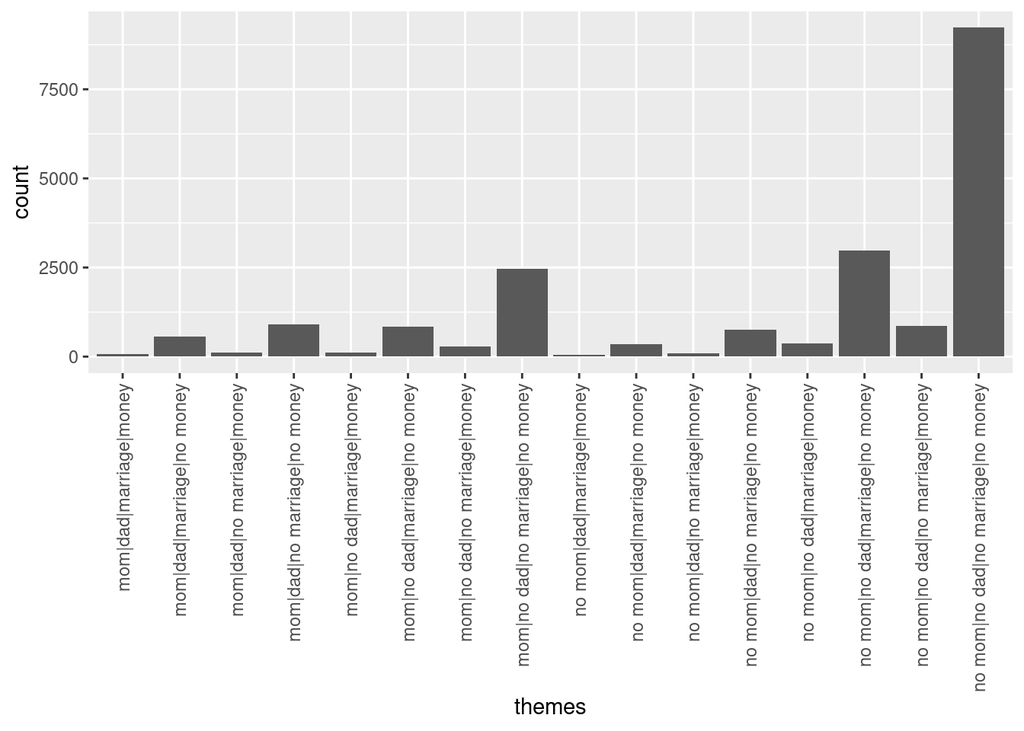

```r
ggplot(abby, aes(x = themes)) +
    geom_bar() +
    theme(axis.text.x = element_text(angle = 90, vjust = 0.5, hjust=1))
```

3. Counts in the table below match the barplot

```r
# Construct a table of counts
abby %>%
    count(themes)
```

```
# A tibble: 16 × 2
   themes                                 n
   <chr>                              <int>
 1 mom|dad|marriage|money                67
 2 mom|dad|marriage|no money            567
 3 mom|dad|no marriage|money            109
 4 mom|dad|no marriage|no money         906
 5 mom|no dad|marriage|money            121
 6 mom|no dad|marriage|no money         839
 7 mom|no dad|no marriage|money         293
 8 mom|no dad|no marriage|no money     2462
 9 no mom|dad|marriage|money             41
10 no mom|dad|marriage|no money         350
11 no mom|dad|no marriage|money          96
12 no mom|dad|no marriage|no money      760
13 no mom|no dad|marriage|money         360
14 no mom|no dad|marriage|no money     2967
15 no mom|no dad|no marriage|money      865
16 no mom|no dad|no marriage|no money  9231
```

4. What do the plot layers do?

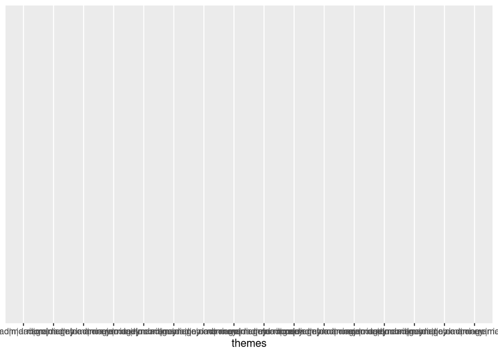

```r
# Just sets up the "canvas" of the plot with axis labels
ggplot(abby, aes(x = themes))
```

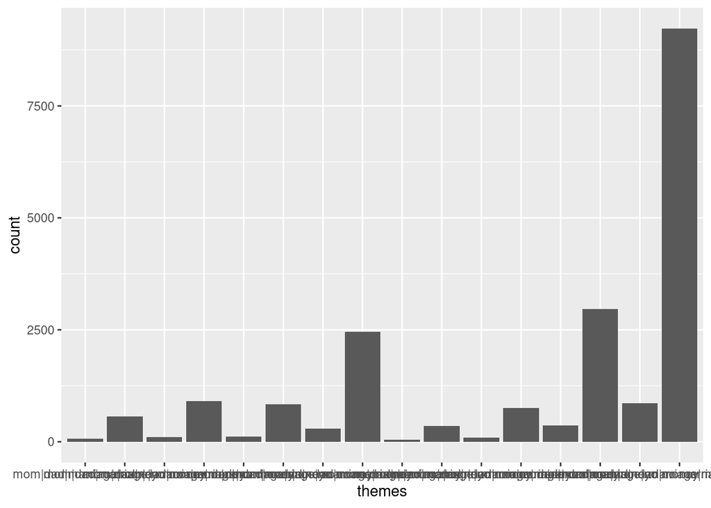

```r
# Adds the bars
ggplot(abby, aes(x = themes)) +
    geom_bar()
```

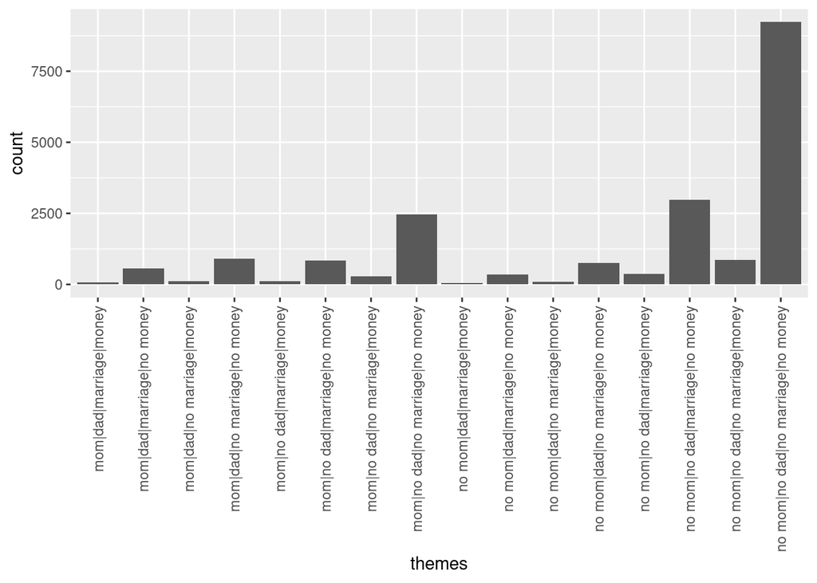

```r
# Rotates the x axis labels
ggplot(abby, aes(x = themes)) +
    geom_bar() +
    theme(axis.text.x = element_text(angle = 90, vjust = 0.5, hjust=1))
```

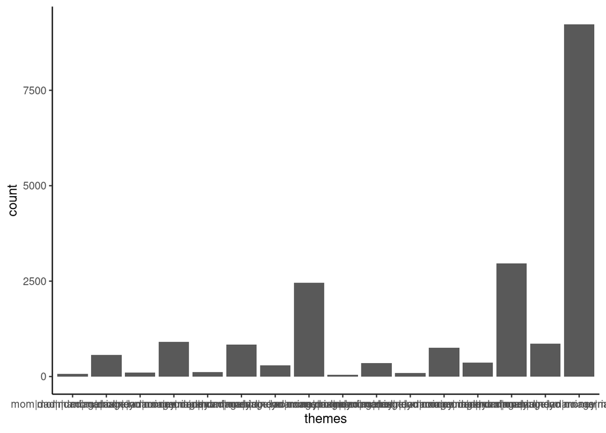

```r
# Changes the visual theme of the plot with a white background and removes gridlines
ggplot(abby, aes(x = themes)) +
    geom_bar() +
    theme(axis.text.x = element_text(angle = 90, vjust = 0.5, hjust=1)) +
    theme_classic()
```

## Exercise 5: Exploring course overall ratings

1. - We might expect the mean of this variable is less than zero given that more negative words might be appear in questions on an advice column.
   - The code has a similar structure to the barplot in that there is an initial `ggplot()` layer which sets the canvas, then a `+` to add a layer, then the final layer `geom_boxplot()` (like `geom_bar()`) which tells R what type of plot to make.

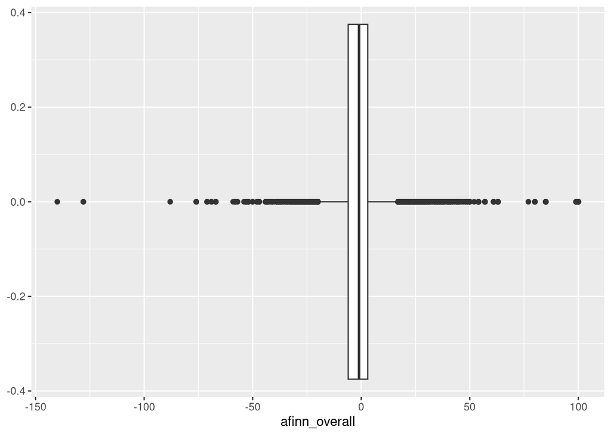

```r
ggplot(abby, aes(x = afinn_overall)) +
    geom_boxplot()
```

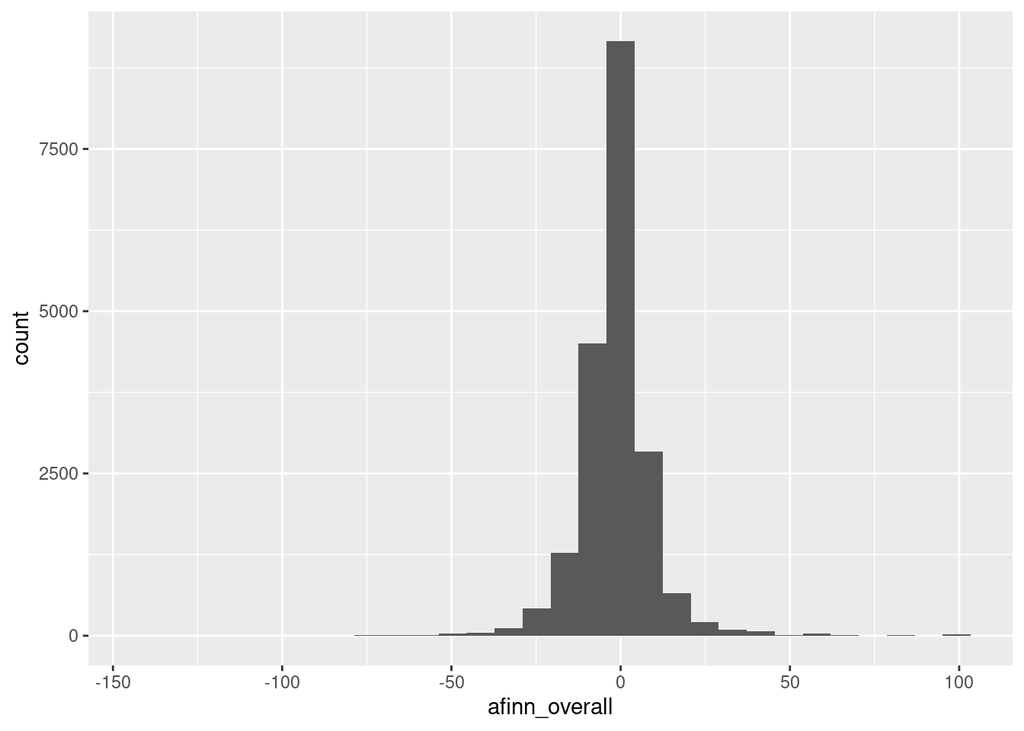

```r
# Histogram
ggplot(abby, aes(x = afinn_overall)) +
    geom_histogram()
```

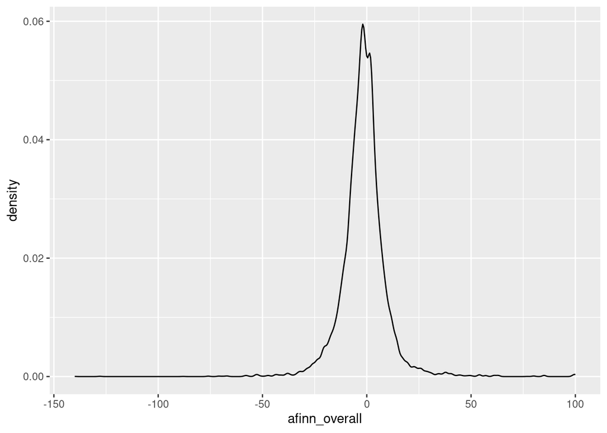

```r
# Density plot
ggplot(abby, aes(x = afinn_overall)) +
    geom_density()
```

3. - Boxplot shows min, max, median, 1st and 3rd quartile easily. (It shows median, 1st and 3rd quartile directly as lines)
   - Histogram and density plot show min and max but the mean and median aren’t shown directly–we have to roughly guess based on the peak of the distribution

```r
# Summary statistics
summary(abby$afinn_overall)
```

```
    Min.  1st Qu.   Median     Mean  3rd Qu.     Max.     NA's
-140.000   -6.000   -1.000   -1.401    3.000  100.000      490
```

```r
abby %>%
    summarize(mean(afinn_overall, na.rm = TRUE), median(afinn_overall, na.rm = TRUE), sd(afinn_overall, na.rm = TRUE))
```

```
# A tibble: 1 × 3
  mean(afinn_overall, na.rm = TR…¹ median(afinn_overall…² sd(afinn_overall, na…³
                             <dbl>                  <dbl>                  <dbl>
1                            -1.40                     -1                   11.1
# ℹ abbreviated names: ¹`mean(afinn_overall, na.rm = TRUE)`,
#   ²`median(afinn_overall, na.rm = TRUE)`, ³`sd(afinn_overall, na.rm = TRUE)`
```

4. The distribution of sentiment scores is roughly symmetric with a mean of -1.4 and a similar median of -1. The median and mean are quite similar because the distribution is fairly symmetric. The standard deviation of the sentiment scores is about 11.08 which tells us how much variation there is from the center of the distribution. 11.08 is somewhat high given the IQR of -6 to 3 (which is a span of 9 units).

## Exercise 6: Box plots vs. histograms vs. density plots

1. Boxplots very clearly show key summary statistics like median, 1st and 3rd quartile
2. Boxplots can oversimplify by not showing the shape of the distribution.

## Exercise 7: Explore outliers

There are some positive words in the questions that seem to pull up the sentiment score a lot despite the negative overall tone. From this we can see the limitations of a basic sentiment analysis in which the sentiment of each word is considered in isolation.

```r
abby %>%
    filter(afinn_overall > 50) %>%
    pull(question_only) %>%
    head() # Just to look at first 6
```

```
[1] "i am a 36-year-old college dropout whose lifelong ambition was to be a physician. i have a very good job selling pharmaceutical supplies, but my heart is still in the practice of medicine. i do volunteer work at the local hospital on my time off, and people tell me i would have made a wonderful…
[2] "we have an only child--a grown daughter we dearly love--and when we pass on, we want to leave her our entire estate, which is considerable.\nthe thing that troubles us is this: our daughter is married to a very unworthy character. for years he has taken advantage of her sweet, forgiving, genero…
[3] "both of our sons have been married for about 15 years. their wives were of normal weight when they married our sons, but one daughter-in- law weighs about 300 pounds and the other weighs about 225. their ages are 35 and 37. both our sons are good-looking, and neither is fat.\nour daughters-in-l…
[4] "the letter from \"concerned mom,\" who was trying to teach her 5-year-old not to accept gifts from strangers, prompts this letter.\na gentleman friend of mine recently stood in line behind a mother and her young daughter at a bank. the child remarked on the visor he was wearing, as it had the n…
[5] "in january, i sent an original manuscript as a gift to woody allen. i had hand-bound the pages, and decorated the binding with baroque pearls and amethyst. i enclosed my name, address and telephone number. i had hoped that woody would send me a note or call me, or at the very least, instruct hi…
[6] "will you please, please discourage high school and college graduates from sending graduation invitations to every distant relative they and their parents ever heard of? we all know that sending \"invitations\" to people we hardly know is a flagrant, shameless bid for a gift. and if, in a moment…
```

## Exercise 8: Returning to our context, looking ahead

- Answers will vary

## Exercise 11: Read in and get to know the weather data

```r
weather <- read_csv("https://raw.githubusercontent.com/Mac-STAT/data/main/weather_3_locations.csv")
```

## Exercise 12: Exploring the data structure

Check out the basic features of the weather data.

```r
# Examine the first six cases
head(weather)
```

```
# A tibble: 6 × 24
  date       location  mintemp maxtemp rainfall evaporation sunshine windgustdir
  <date>     <chr>       <dbl>   <dbl>    <dbl>       <dbl>    <dbl> <chr>
1 2020-01-01 Wollongo…    17.1    23.1        0          NA       NA SSW
2 2020-01-02 Wollongo…    17.7    24.2        0          NA       NA SSW
3 2020-01-03 Wollongo…    19.7    26.8        0          NA       NA NE
4 2020-01-04 Wollongo…    20.4    35.5        0          NA       NA SSW
5 2020-01-05 Wollongo…    19.8    21.4        0          NA       NA SSW
6 2020-01-06 Wollongo…    18.3    22.9        0          NA       NA NE
# ℹ 16 more variables: windgustspeed <dbl>, winddir9am <chr>, winddir3pm <chr>,
#   windspeed9am <dbl>, windspeed3pm <dbl>, humidity9am <dbl>,
#   humidity3pm <dbl>, pressure9am <dbl>, pressure3pm <dbl>, cloud9am <dbl>,
#   cloud3pm <dbl>, temp9am <dbl>, temp3pm <dbl>, raintoday <chr>,
#   risk_mm <dbl>, raintomorrow <chr>
```

```r
# Find the dimensions of the data
dim(weather)
```

```
[1] 2367   24
```

A case represents a day of the year in a particular area (Hobart, Uluru, Wollongong as seen by the `location` variable).

## Exercise 13: Exploring rainfall

The `raintoday` variable contains information about rainfall.

- `raintoday` is categorical (No, Yes)
- It is more common to have no rain.

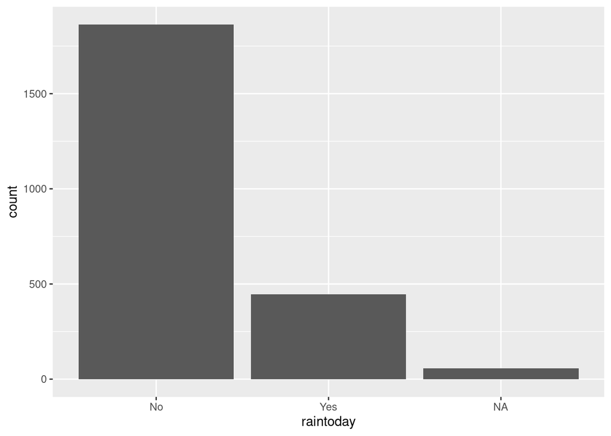

```r
# Visualization
ggplot(weather, aes(x = raintoday)) +
    geom_bar()
```

```r
# Numerical summaries
weather %>%
    count(raintoday)
```

```
# A tibble: 3 × 2
  raintoday     n
  <chr>     <int>
1 No         1864
2 Yes         446
3 <NA>         57
```

## Exercise 14: Exploring temperature

The `maxtemp` variable contains information on the daily high temperature.

- `maxtemp` is quantitative
- The *typical* max temperature is around 23 degrees Celsius (with an average of 23.62 and a median of 22 degrees). The max temperatures ranged from 8.6 to 45.4 degrees. Finally, on the typical day, the max temp falls about 7.8 degrees from the mean. There are multiple modes in the distribution of max temperature—this likely reflects the different cities in the dataset.

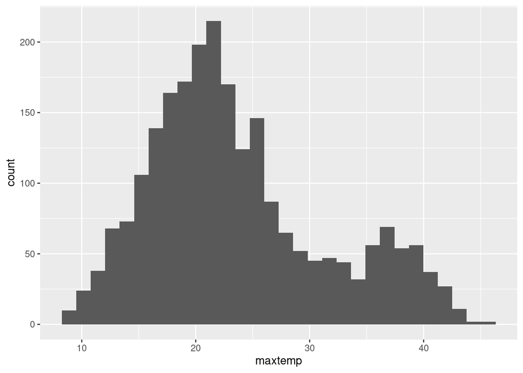

```r
# Visualization
ggplot(weather, aes(x = maxtemp)) +
    geom_histogram()
```

```r
# Numerical summaries
summary(weather$maxtemp)
```

```
   Min. 1st Qu.  Median    Mean 3rd Qu.    Max.    NA's
   8.60   18.10   22.00   23.62   27.40   45.40      34
```

```r
# There are missing values (NAs) in this variable, so we add
# the na.rm = TRUE argument
weather %>%
    summarize(sd(maxtemp, na.rm = TRUE))
```

```
# A tibble: 1 × 1
  `sd(maxtemp, na.rm = TRUE)`
                        <dbl>
1                        7.80
```